# Differential methylation: probes (DMP) and regions (DMR)

RSTR vs. LTBI, full dataset

Kim Dill-McFarland, kadm@uw.edu

version November 10, 2022

# Background

This workflow identifies differentially methylated probes (DMP) between RSTR / LTBI and then uses these probes to collate differentially methylated regions (DMR). Models are corrected for age, sex, and kinship when available.

# Setup

Load packages

```r
# Linear regression
library(limma)
library(kimma)

# DMR analysis
library(DMRcate)

#GSEA
library(org.Hs.eg.db)

# Data manipulation and figures
library(tidyverse)
  # Manhattan plots (GitHub package)
  library(ggman)

#Print pretty tables to Rmd
library(knitr)
library(kableExtra)
```

Set seed

```r
set.seed(589)
```

# Load data

```r
load("data_Methyl_clean/methyl_data.RData")
probes <- read_csv("data_Methyl_clean/RSTR_probe_features.csv.gz")
ls()
```

```
## [1] "kin"        "meta"       "meta.kin"   "probes"     "RSTR.M"
## [6] "RSTR.M.kin"
```

# Differential methylation

## Probe-level

Determine differential methylation of probes (DMP) using a linear mixed effects model. See 2.Methyl_model_selection.html for further details.

```r
attach("results/model_selection/kinship_final_model.RData")
DMP.results <- kinship_final$lmerel %>%
  dplyr::rename(probeID = gene)
```

Calculate average M values for RSTR vs LTBI and merge with probe info and model results.

```r
M.ave <- as.data.frame(RSTR.M.kin) %>%
  rownames_to_column("probeID") %>%
  #Convert to long format for calculations
  pivot_longer(-probeID, names_to="Sample_Name", values_to="M") %>%
  #Add group metadata
  inner_join(dplyr::select(meta.kin, Sample_Name, Sample_Group),
            by="Sample_Name") %>%
  #Calculate mean for each probe in each sample group
  group_by(Sample_Group, probeID) %>%
  dplyr::summarize(M.ave = mean(M, na.rm=TRUE),
                   M.sd = sd(M, na.rm=TRUE)) %>%
  ungroup() %>%
  #Return to wide format
  pivot_longer(M.ave:M.sd) %>%
  mutate(name = paste(Sample_Group,name,sep=".")) %>%
  dplyr::select(-Sample_Group) %>%
  pivot_wider()

B.ave <- read_csv("data_Methyl_clean/RSTR_clean_beta.csv.gz") %>%
  #Convert to long format for calculations
  pivot_longer(-probeID, names_to="Sample_Name", values_to="B") %>%
  #Add group metadata
  inner_join(dplyr::select(meta.kin, Sample_Name, Sample_Group),
            by="Sample_Name") %>%
  #Calculate mean for each probe in each sample group
  group_by(Sample_Group, probeID) %>%
  dplyr::summarize(B.ave = mean(B, na.rm=TRUE),
                   B.sd = sd(B, na.rm=TRUE)) %>%
  ungroup() %>%
  #Return to wide format
  pivot_longer(B.ave:B.sd) %>%
  mutate(name = paste(Sample_Group,name,sep=".")) %>%
  dplyr::select(-Sample_Group) %>%
  pivot_wider()

#####
DMP.results.all <- DMP.results %>%
  filter(variable == "Sample_Group") %>%
  #merge with other data
  left_join(probes, by="probeID") %>%
  full_join(M.ave, by="probeID") %>%
  full_join(B.ave, by="probeID")
```

Save final DMP results.

```r
write.table(DMP.results.all, sep=",",
            row.names=FALSE, col.names=TRUE,
            file=gzfile("./results/RSTR.DMP.results.csv.gz"))
```

### Visualize DMP

#### Manhatten plot

```
## # A tibble: 5 × 4
##   variable             fdr_0.05 fdr_0.2 fdr_0.5
##   <fct>                   <int>   <int>   <int>
## 1 (1 | FULLIDNO)             21      48     127
## 2 KCHCA_AGE_YR_CURRENT     5602   14775   46153
## 3 M0_KCVSEX                1905    4895   12738
## 4 Sample_Group               13     174    1580
## 5 total (nonredundant)     7492   19577   58538
```

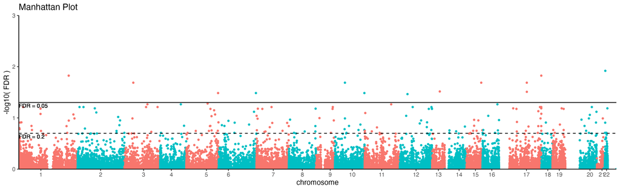

Save plot.

```r
# ggsave("figs/DMP_Manhattan_plot.pdf", DMP.man.plot,
#        width = 13, height=4)
ggsave("figs/DMP_Manhattan_plot.png", DMP.man.plot,
       width = 13, height=4)
```

#### Individual DMP plots

Save methylation plots in `figs/DMP_plots/`

## Region-level

Several methods are available for the identification of differentially methylated regions (DMR) including Bumphunter, DMRcate, and ProbeLasso. These are compared in detail using 450K methylation data in [Mallik S *et al* 2018](https://academic.oup.com/bib/advance-article/doi/10.1093/bib/bby085/5096828) and [Peters TJ *et al* 2014](https://epigeneticsandchromatin.biomedcentral.com/articles/10.1186/1756-8935-8-6). Of those available in R, DMRcate performed the best and allows co-variate variables.

Thus, using DMRcate, we will identify DMRs around significant probes.

### DMRcate

Run DMRcate on 174 probes with FDR $\leq$ 0.2 and call significant regions with default DMRcate region FDR.

This results in only 35 DMR at the auto-generated FDR cutoff of 8.1627998^{-85}. Thus, a more lenient FDR will be explored. Here, we see all DMR with FDR < 0.05 and select the top.

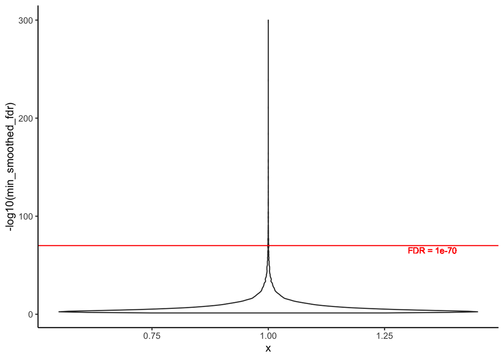

Thus, we use a new DMR FDR cutoff of 10^{-70}, which results in 63 DMR.

### Annotate DMRs

Extract the probes that occur within significant DMRs. Re-calculate DMR ranges based on hg38 probe mapping.

#### Save DMR results

```r
write_csv(DMR.M.results, "results/RSTR.DMR.results.csv")

write.table(DMR.M.results.CpG, sep=",",
            row.names=FALSE, col.names=TRUE,
            file=gzfile("results/RSTR.DMR.results.cpgs.csv.gz"))
```

### Visualize DMR

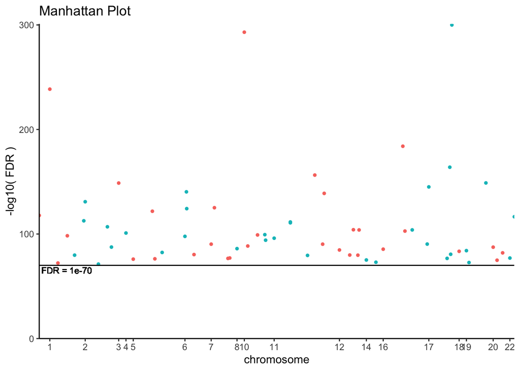

Save plot.

```r
# ggsave("figs/DMR_Manhattan_plot.pdf", DMR.man.plot,
#        width = 13, height=4)
ggsave("figs/DMR_Manhattan_plot.png", DMR.man.plot,
       width = 13, height=4)
```

#### Individual DMR plots

Save DMR plots in `/figs/DMR_plots/`